# Project 1

Raul Miranda

10/12/2020

### Load libraries

```r
library(tidyverse)
library(ggplot2)
library(psych)
library(RColorBrewer)
library(lubridate)
# install.packages("devtools")
# devtools::install_github("thomasp85/patchwork")   # it may be outdated
# package "patchwork" is used to combine ggplots into same graph
# information at https://patchwork.data-imaginist.com)
# install.packages("patchwork", repos = "https://cran.rstudio.com/bin/macosx/contrib/4.0/patchwork_1.0.1.tgz")
# devtools::install_github("pdil/usmap")
library(patchwork)
library(usmap)
```

### Read datasets

```r
setwd("/Users/raulmiranda/Desktop/DATA 110 Fall 2020/Databases")
mpv <- read.csv("MPVDatasetDownload.csv")
# mpv_PD <- read.csv("MPVDataset_by PD.csv")        # not used in this project
# mpv_State <- read.csv("MPVDataset_by State.csv")  # not used in this project
# str(mpv)
# mpv
```

### Clean the dataset:

Select and rename: Age, Gender, Race, Date, City, State, Zipcode, County, Agency, Cause, Disposition, Charges, Mental, Unarmed, Weapon, Threat, Fleeing, Camera

Clean the gender and race columns

```r
mpv_clean <- select(mpv, "age"="Victim.s.age", "gender"="Victim.s.gender", "race"="Victim.s.race", "date"="Date.of.Incident..month.day.year.", "city"="City", "state"="State","zip"= "Zipcode", "agency"="Agency.responsible.for.death", "cause" = "Cause.of.death", "disposition" = "Official.disposition.of.death..justified.or.other.", "charges" = "Criminal.Charges.", "mental" = "Symptoms.of.mental.illness.", "unarmed"="Unarmed.Did.Not.Have.an.Actual.Weapon", "weapon" = "Alleged.Weapon..Source..WaPo.and.Review.of.Cases.Not.Included.in.WaPo.Database.", "threat"="Alleged.Threat.Level..Source..WaPo.", "fleeing"="Fleeing..Source..WaPo.", "camera"="Body.Camera..Source..WaPo.")
mpv_clean$gender <- trimws(mpv_clean$gender)   # remove trailing spaces in gender column
mpv_clean$gender [mpv_clean$gender == ""] <- "Unknown"
mpv_clean$race   [mpv_clean$race == "Native American"] <- "Native"
mpv_clean$race   [mpv_clean$race == "Pacific Islander"] <- "Pacific"
mpv_clean$race   [mpv_clean$race == "Unknown race"] <- "Unknown"
# mpv_clean
```

### Exploratory analysis: check gender distribution

```r
mpv_gender <- group_by (mpv_clean, gender) %>% summarise(shootings=n())
mpv_gender
```

```
## # A tibble: 4 x 2
##   gender      shootings
##   <chr>           <int>
## 1 Female            423
## 2 Male             8036
## 3 Transgender         9
## 4 Unknown            17
```

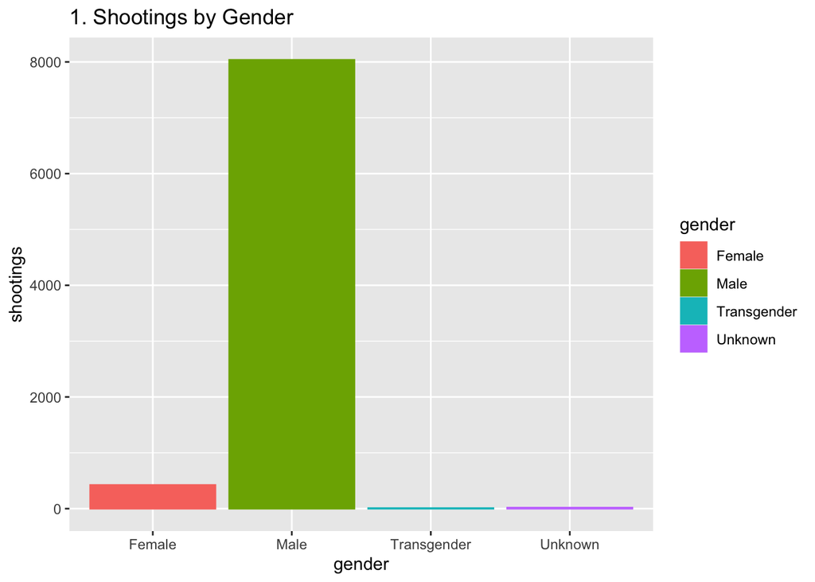

```r
ggplot(mpv_gender, aes(gender, shootings, color=gender, fill=gender, na.rm=TRUE)) +
  geom_bar(stat="identity") +  labs (title = "1. Shootings by Gender")
```

### Exploratory analysis: check race, gender distribution

```r
mpv_racegender1 <- filter(mpv_clean, race==c("White", "Black", "Hispanic")) %>%
    group_by (race, gender) %>% summarise(shootings=n())
mpv_racegender1
```

```
## # A tibble: 8 x 3
## # Groups:   race [3]
##   race     gender      shootings
##   <chr>    <chr>           <int>
## 1 Black    Female             16
## 2 Black    Male              678
## 3 Hispanic Female             23
## 4 Hispanic Male              443
## 5 White    Female             81
## 6 White    Male             1140
## 7 White    Transgender         2
## 8 White    Unknown             1
```

```r
mpv_racegender2 <- filter(mpv_clean, race==c("Asian", "Pacific", "Native", "Unknown")) %>%
    group_by (race, gender) %>% summarise(shootings=n())
mpv_racegender2
```

```
## # A tibble: 9 x 3
## # Groups:   race [4]
##   race    gender  shootings
##   <chr>   <chr>       <int>
## 1 Asian   Female          2
## 2 Asian   Male           23
## 3 Native  Female          2
## 4 Native  Male           30
## 5 Native  Unknown         1
## 6 Pacific Male           14
## 7 Unknown Female         13
## 8 Unknown Male          228
## 9 Unknown Unknown         4
```

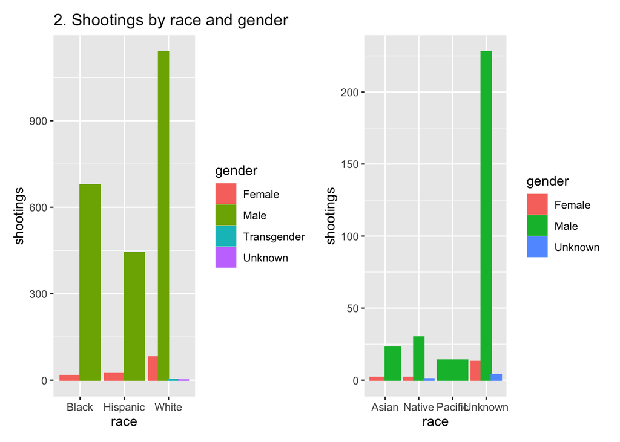

```r
p1 <- ggplot(mpv_racegender1, aes(race, shootings, color=gender, fill=gender)) +
        geom_bar(stat="identity", position="dodge") +  labs (title = "2. Shootings by race and gender")
p2 <- ggplot(mpv_racegender2, aes(race, shootings, color=gender, fill=gender)) +
        geom_bar(stat="identity", position="dodge")
p1 + p2    # patchwork command to combine plots
```

### Exploratory analysis: check time distribution and cumulative shootings

```r
mpv_date <- filter (mpv_clean) %>%
  group_by (gender, date=mdy(date)) %>%     # group by gender and convert dates to date format
  summarise(shootings=n()) %>%              # add up shootings by gender
  mutate(total=cumsum(shootings))           # add cumulative total
mpv_date                                    # data frame of shootings per day and cumulative
```

```
## # A tibble: 3,058 x 4
## # Groups:   gender [4]
##    gender date       shootings total
##    <chr>  <date>         <int> <int>
##  1 Female 2013-01-04         1     1
##  2 Female 2013-01-08         1     2
##  3 Female 2013-01-09         2     4
##  4 Female 2013-01-22         1     5
##  5 Female 2013-01-24         1     6
##  6 Female 2013-01-29         1     7
##  7 Female 2013-01-30         1     8
##  8 Female 2013-02-08         1     9
##  9 Female 2013-02-19         1    10
## 10 Female 2013-03-16         1    11
## # … with 3,048 more rows
```

```r
mpv_date1 <- filter (mpv_clean, gender=="Male") %>%
  group_by (gender, date=mdy(date)) %>%     # as above for males
  summarise(shootings=n()) %>%
  mutate(total=cumsum(shootings))
mpv_date1                                   # shootings per day and cumulative for males
```

```
## # A tibble: 2,647 x 4
## # Groups:   gender [1]
##    gender date       shootings total
##    <chr>  <date>         <int> <int>
##  1 Male   2013-01-01         6     6
##  2 Male   2013-01-02         1     7
##  3 Male   2013-01-03         3    10
##  4 Male   2013-01-04         5    15
##  5 Male   2013-01-05         6    21
##  6 Male   2013-01-06         4    25
##  7 Male   2013-01-07         3    28
##  8 Male   2013-01-08         1    29
##  9 Male   2013-01-09         1    30
## 10 Male   2013-01-10         3    33
## # … with 2,637 more rows
```

```r
mpv_date2 <- filter (mpv_clean, gender==c("Female" , "Transgender", "Unknown")) %>%
  group_by (gender, date=mdy(date)) %>%     # as above for females and other genders
  summarise(shootings=n()) %>%
  mutate(total=cumsum(shootings))
mpv_date2                                   # shootings per day and cumulative for females and others
```

```
## # A tibble: 136 x 4
## # Groups:   gender [3]
##    gender date       shootings total
##    <chr>  <date>         <int> <int>
##  1 Female 2013-01-08         1     1
##  2 Female 2013-01-09         1     2
##  3 Female 2013-01-30         1     3
##  4 Female 2013-02-19         1     4
##  5 Female 2013-04-09         1     5
##  6 Female 2013-05-15         1     6
##  7 Female 2013-05-17         1     7
##  8 Female 2013-05-30         1     8
##  9 Female 2013-06-05         1     9
## 10 Female 2013-06-23         1    10
## # … with 126 more rows
```

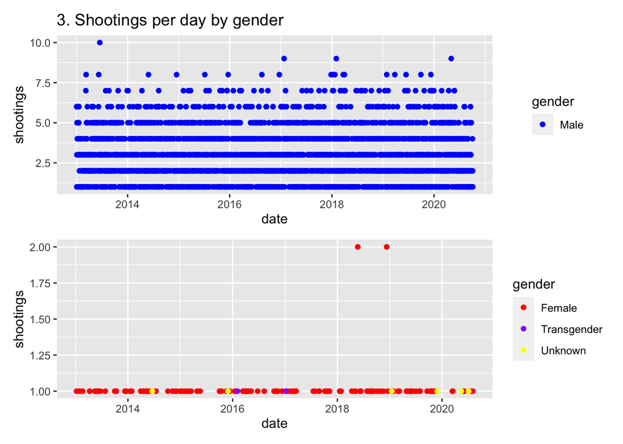

```r
p3<- ggplot(mpv_date1) +
   geom_point(aes(date,shootings, colour = gender)) + scale_color_manual(values = "blue") +
    labs (title = "3. Shootings per day by gender")
p4<- ggplot(mpv_date2) +
   geom_point(aes(date,shootings, colour = gender)) + scale_color_manual(values = c("red", "purple", "yellow"))
p5<- ggplot(mpv_date1)+
   geom_point(aes(date,total, colour = gender)) + scale_color_manual(values = "blue") +
    labs (title = "4. Accumulated shootings over time by gender")
p6<- ggplot(mpv_date2)+
   geom_point(aes(date,total, colour = gender)) + scale_color_manual(values = c("red", "purple", "yellow"))
p7<- ggplot(mpv_date) +
   geom_point(aes(date,total, colour = gender)) +
     facet_wrap(~gender) + scale_color_manual(values = c("red", "blue", "purple", "yellow")) +
    labs (title = "5. All together: facet-wrap of accumulated shootings over time by gender")
p3 / p4   # patchwork command to combine plots
```

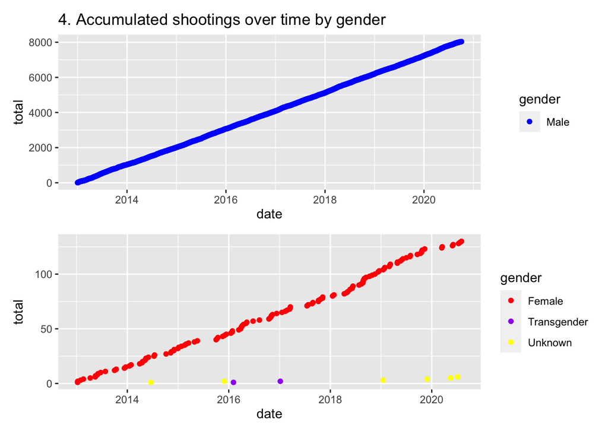

```r
p5 / p6
```

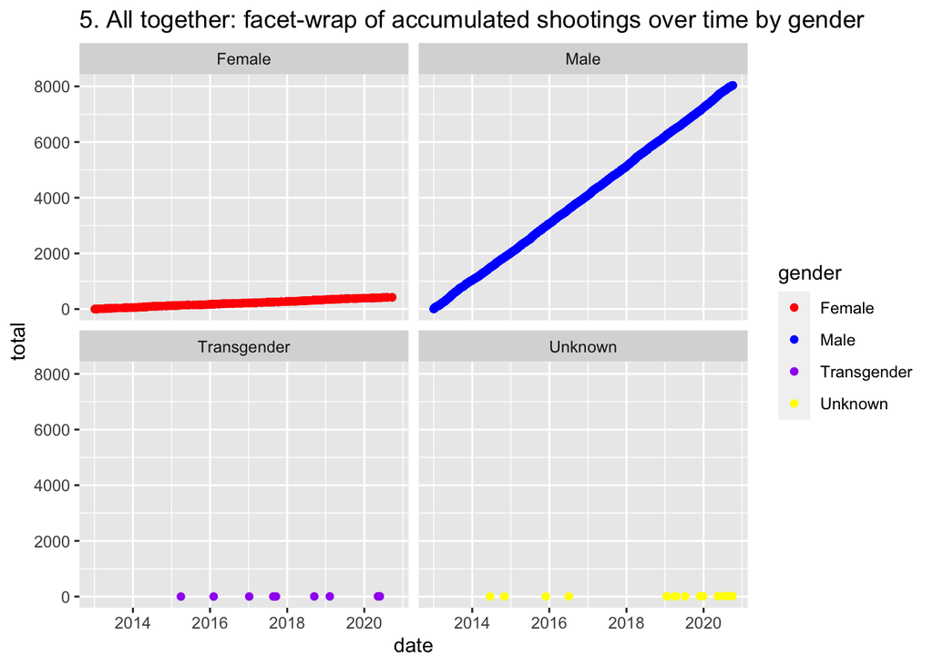

```r
p7
```

### Exploratory analysis: check age distribution

```r
mpv_age <- mpv_clean %>% group_by (age=as.numeric(age)) %>%
summarise(shootings=n())
mpv_age
```

```
## # A tibble: 87 x 2
##      age shootings
##    <dbl>     <int>
##  1     1         3
##  2     5         3
##  3     6         3
##  4     7         1
##  5    10         1
##  6    12         2
##  7    13         2
##  8    14         6
##  9    15        20
## 10    16        46
## # … with 77 more rows
```

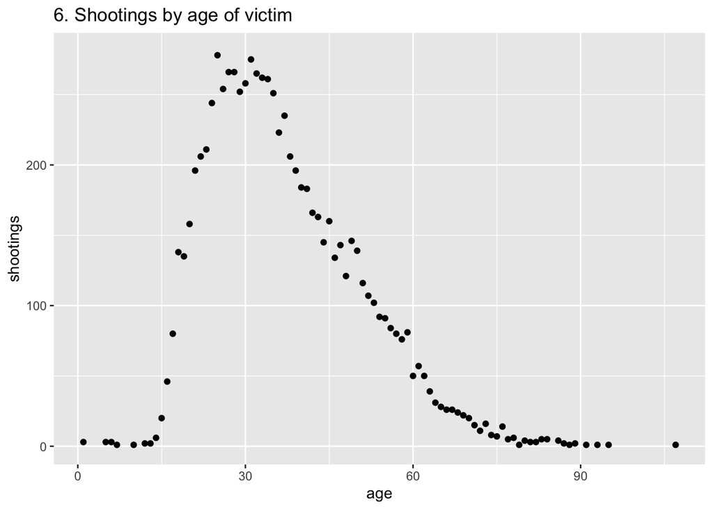

```r
# plot(mpv_age)             # simple plot
p7 <- ggplot(mpv_age) +     # try out the same with ggplot
        geom_point(aes(age,shootings)) + labs (title = "6. Shootings by age of victim")
p7
```

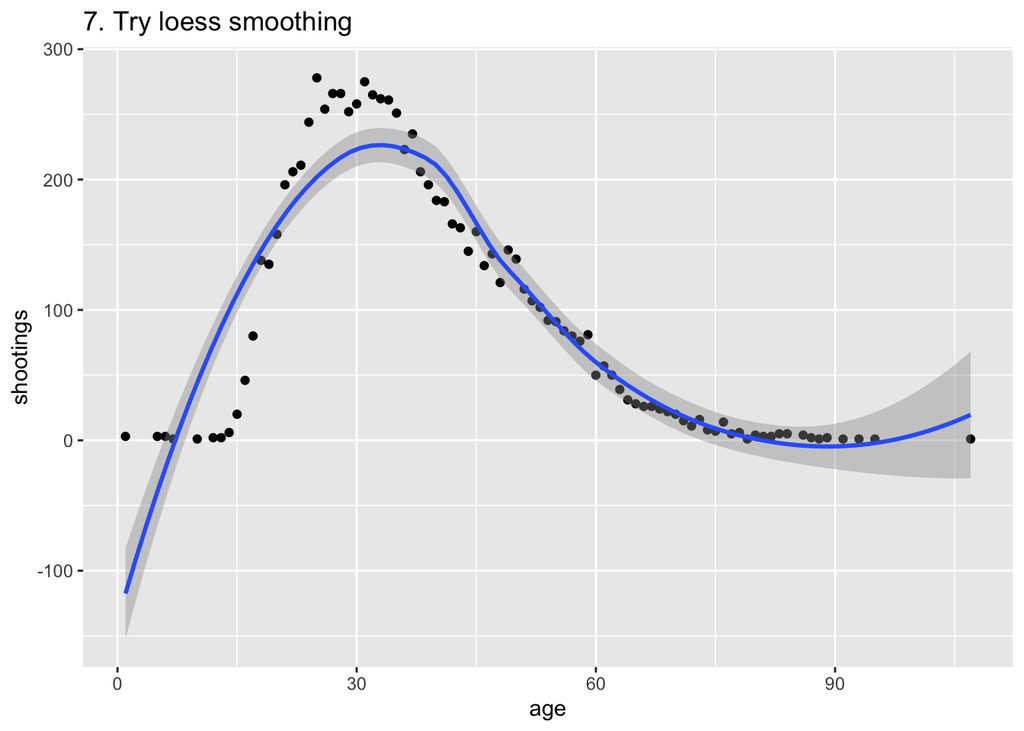

```r
p7 +   geom_smooth(aes(age,shootings)) + # explore loess smoothing
                    labs (title = "7. Try loess smoothing")
```

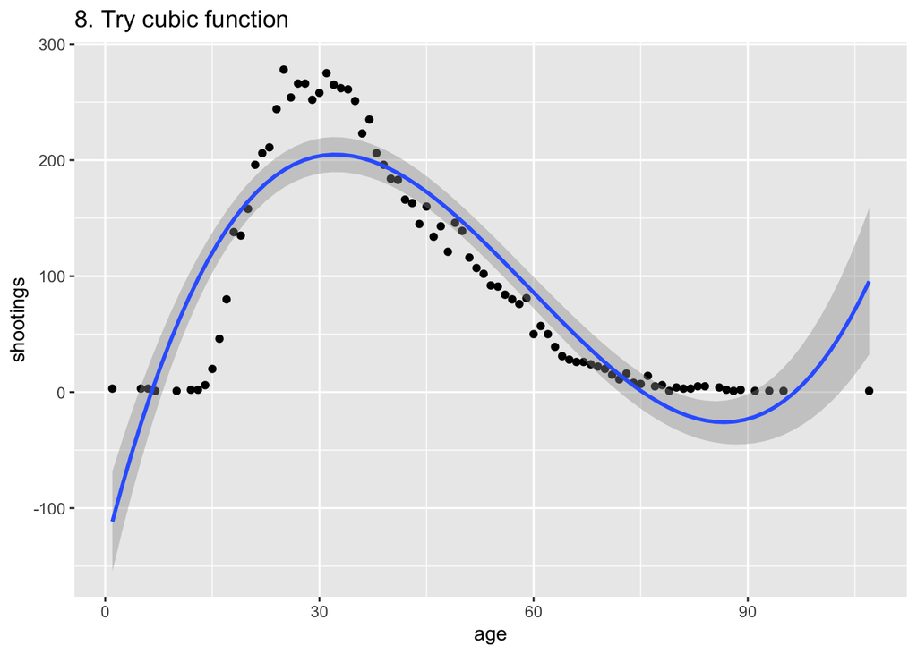

```r
p7 +   geom_smooth(aes(age,shootings), method="lm", formula=y~poly(x,3)) +  #  explore cubic smooting
                    labs (title = "8. Try cubic function")
```

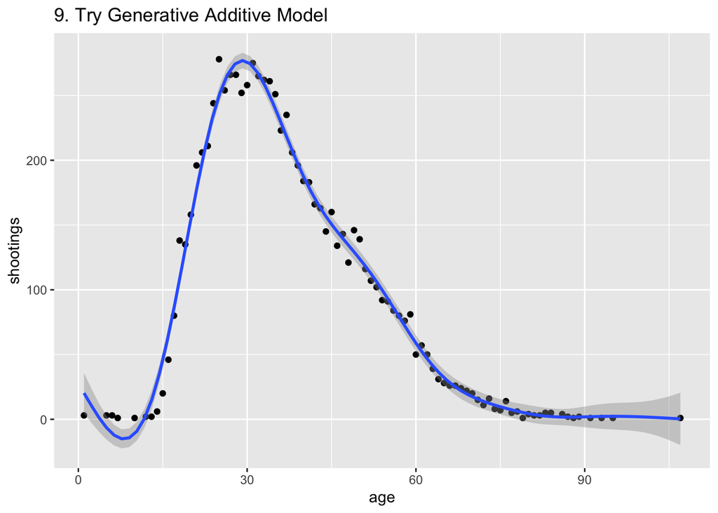

```r
p7 +   geom_smooth(aes(age,shootings), method="gam", formula=y~s(x)) +   #  explore a Gen. Additive Model
                    labs (title = "9. Try Generative Additive Model")
```

### Cleaner analysis of interaction between age and race

```r
mpv_age_race <- filter(mpv_clean, race==c("White", "Black", "Hispanic")) %>%  # filter race
  group_by (race, age=as.numeric(age)) %>%                                    # group by age
summarise(shootings=n())                                                      # count shootings
mpv_age_race
```

```
## # A tibble: 186 x 3
## # Groups:   race [3]
##    race    age shootings
##    <chr> <dbl>     <int>
##  1 Black    13         1
##  2 Black    15         3
##  3 Black    16         7
##  4 Black    17        11
##  5 Black    18        18
##  6 Black    19        18
##  7 Black    20        25
##  8 Black    21        34
##  9 Black    22        21
## 10 Black    23        24
## # … with 176 more rows
```

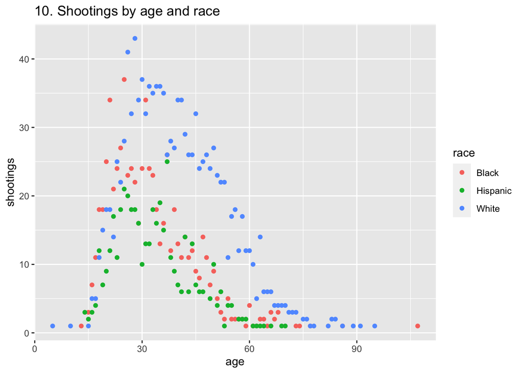

```r
p8 <- ggplot(mpv_age_race) +
        geom_point(aes(age,shootings, color= race))  +  labs (title = "10. Shootings by age and race")
p8
```

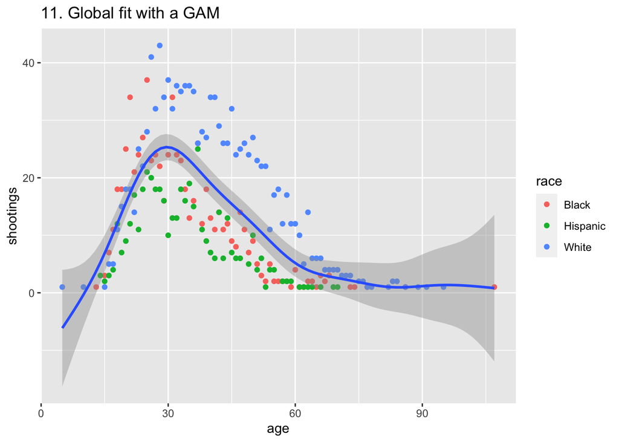

```r
p8 +   geom_smooth(aes(age,shootings), method="gam", formula=y~s(x)) + # use a GAM for global fit
                       labs (title = "11. Global fit with a GAM")
```

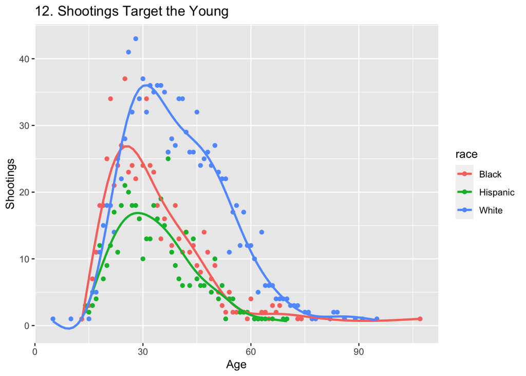

```r
p8 +   geom_smooth(aes(age,shootings, color=race), method="gam", formula=y~s(x), se=FALSE) + # without SE
        labs (title = "12. Shootings Target the Young", x="Age", y="Shootings")
```

### Analysis of death distribution by State and cause of death over the 2013-2020 period

```r
mpv_state <- mpv_clean %>% group_by(state) %>% summarise(deaths=n())
mpv_state
```

```
## # A tibble: 51 x 2
##    state deaths
##    <chr>  <int>
##  1 AK        47
##  2 AL       153
##  3 AR       117
##  4 AZ       375
##  5 CA      1306
##  6 CO       267
##  7 CT        40
##  8 DC        27
##  9 DE        21
## 10 FL       611
## # … with 41 more rows
```

```r
mpv_state_cause <- filter(mpv_clean, grepl("Gunshot",cause) | grepl("^Taser",cause) | cause=="Asphyxiated" | grepl("Beaten", cause) | cause=="Physical Restraint" | cause =="Vehicle" )   %>%
  group_by (state, cause) %>% summarise(deaths=n())
mpv_state_cause
```

```
## # A tibble: 225 x 3
## # Groups:   state [51]
##    state cause               deaths
##    <chr> <chr>                <int>
##  1 AK    Gunshot                 46
##  2 AK    Gunshot, Taser           1
##  3 AL    Beaten                   1
##  4 AL    Gunshot                139
##  5 AL    Gunshot, Taser           5
##  6 AL    Taser                    7
##  7 AL    Tasered                  1
##  8 AR    Beaten                   1
##  9 AR    Gunshot                109
## 10 AR    Gunshot, Police Dog      1
## # … with 215 more rows
```

### Generate a USA map for further plots

```r
#head(us_map())
#head(statepop)
#plot_usmap("states")

p9 <- plot_usmap(data =statepop, values="pop_2015") +  #add labels=T if state Abbrev are desired
  scale_fill_continuous(low="white", high="blue", name="Population (2015)", label=scales::comma,
                        guide=guide_colorbar(barwidth=15, barheight=0.5, title.position = "top")) +
                       labs(title = "13. State Population",
                       subtitle = "in 2015") +
  theme(panel.background = element_rect(color = "black", fill = "lightblue"), legend.position="bottom")
```

### Join the StatePop dataset of 2015 with the MPV datasets to add a population variable

#### and calculate death rate for each state as (deaths/population) per 1M people

```r
mpv_state_pop <- left_join(mpv_state, statepop[,c("abbr","pop_2015")], by=c("state"="abbr")) %>%
  mutate(deathrate = deaths/pop_2015*1000000)
mpv_state_pop
```

```
## # A tibble: 51 x 4
##    state deaths pop_2015 deathrate
##    <chr>  <int>    <dbl>     <dbl>
##  1 AK        47   738432      63.6
##  2 AL       153  4858979      31.5
##  3 AR       117  2978204      39.3
##  4 AZ       375  6828065      54.9
##  5 CA      1306 39144818      33.4
##  6 CO       267  5456574      48.9
##  7 CT        40  3590886      11.1
##  8 DC        27   672228      40.2
##  9 DE        21   945934      22.2
## 10 FL       611 20271272      30.1
## # … with 41 more rows
```

```r
mpv_state_cause_pop <- left_join(mpv_state_cause, statepop[,c("abbr","pop_2015")], by=c("state"="abbr")) %>%
  mutate(deathrate = deaths/pop_2015*1000000)
mpv_state_cause_pop
```

```
## # A tibble: 225 x 5
## # Groups:   state [51]
##    state cause               deaths pop_2015 deathrate
##    <chr> <chr>                <int>    <dbl>     <dbl>
##  1 AK    Gunshot                 46   738432    62.3
##  2 AK    Gunshot, Taser           1   738432     1.35
##  3 AL    Beaten                   1  4858979     0.206
##  4 AL    Gunshot                139  4858979    28.6
##  5 AL    Gunshot, Taser           5  4858979     1.03
##  6 AL    Taser                    7  4858979     1.44
##  7 AL    Tasered                  1  4858979     0.206
##  8 AR    Beaten                   1  2978204     0.336
##  9 AR    Gunshot                109  2978204    36.6
## 10 AR    Gunshot, Police Dog      1  2978204     0.336
## # … with 215 more rows
```

### Generate a USA mapplot of total deaths for each state for 2013-2020

```r
p10 <- plot_usmap(data= mpv_state_pop, values="deathrate") +  #add labels=T for state abbr
  scale_fill_continuous(low="white", high="red", name="Death Rate per Million Inhabitants", label=scales::comma,
                        guide=guide_colorbar(barwidth=15, barheight=0.5, title.position = "top")) +
 labs(title = "14. All Police-Caused Deaths",
       subtitle = "in the 2013-2020 period") +
  theme(panel.background = element_rect(color = "black", fill = "lightblue"), legend.position="bottom")
```

### Generate a USA mapplot for cumulative deaths by Gunshot for each state

```r
p11 <- plot_usmap(data= filter(mpv_state_cause_pop, grepl("Gunshot",cause)), values="deathrate") +
                            #add labels=T for state abbr
  scale_fill_continuous(low="white", high="purple", name="Death Rate per Million Inhabitants",
                        label=scales::comma,
                        guide=guide_colorbar(barwidth=15, barheight=0.5, title.position = "top")) +
 labs(title = "15. Leading Cause: Gunshots",
       subtitle = "in the 2013-2020 period") +
  theme(panel.background = element_rect(color = "black", fill = "lightblue"), legend.position="bottom")
```

### Map of deaths by Asphyxiation

```r
p12 <- plot_usmap(data= filter(mpv_state_cause_pop, cause=="Asphyxiated"), values="deathrate") +
                            #add labels=T for state abbr
  scale_fill_continuous(low="white", high="yellow", name="Death Rate per Million Inhabitants",
                        label=scales::comma,
                        guide=guide_colorbar(barwidth=15, barheight=0.5, title.position = "top")) +
 labs(title = "16. Leading Cause: Asphyxiation",
       subtitle = "in the 2013-2020 period") +
  theme(panel.background = element_rect(color = "black", fill = "lightblue"), legend.position="bottom")
```

### Map of deaths by Physical Restraint

```r
p13 <- plot_usmap(data= filter(mpv_state_cause_pop, cause=="Physical Restraint"), values="deathrate") +
                            #add labels=T for state abbr
  scale_fill_continuous(low="white", high="chocolate1", name="Death Rate per Million Inhabitants",
                        label=scales::comma,
                        guide=guide_colorbar(barwidth=15, barheight=0.5, title.position = "top")) +
 labs(title = "17. Leading Cause: Physical Restraint",
       subtitle = "in the 2013-2020 period") +
  theme(panel.background = element_rect(color = "black", fill = "lightblue"), legend.position="bottom")
```

### Map of deaths by Beating

```r
p14 <- plot_usmap(data= filter(mpv_state_cause_pop, grepl("Beaten", cause)), values="deathrate") +
                            #add labels=T for state abbr
  scale_fill_continuous(low="white", high="magenta", name="Death Rate per Million Inhabitants",
                        label=scales::comma,
                        guide=guide_colorbar(barwidth=15, barheight=0.5, title.position = "top")) +
 labs(title = "18. Leading Cause: Beaten",
       subtitle = "in the 2013-2020 period") +
  theme(panel.background = element_rect(color = "black", fill = "lightblue"), legend.position="bottom")
```

### Map of deaths by Vehicle

```r
p15 <- plot_usmap(data= filter(mpv_state_cause_pop, cause=="Vehicle"), values="deathrate") +
                            #add labels=T for state abbr
  scale_fill_continuous(low="white", high="aquamarine", name="Death Rate per Million Inhabitants",
                        label=scales::comma,
                        guide=guide_colorbar(barwidth=15, barheight=0.5, title.position = "top")) +
 labs(title = "19. Leading Cause: Vehicle",
       subtitle = "in the 2013-2020 period") +
  theme(panel.background = element_rect(color = "black", fill = "lightblue"), legend.position="bottom")
```

### Map of deaths by Taser

```r
p16 <- plot_usmap(data= filter(mpv_state_cause_pop, grepl("^Taser",cause)), values="deathrate") +
                            #add labels=T for state abbr
  scale_fill_continuous(low="white", high="chartreuse", name="Death Rate per Million Inhabitants",
                        label=scales::comma,
                        guide=guide_colorbar(barwidth=15, barheight=0.5, title.position = "top")) +
 labs(title = "20. Leading Cause: Taser",
       subtitle = "in the 2013-2020 period") +
  theme(panel.background = element_rect(color = "black", fill = "lightblue"), legend.position="bottom")
```

### Present all maps

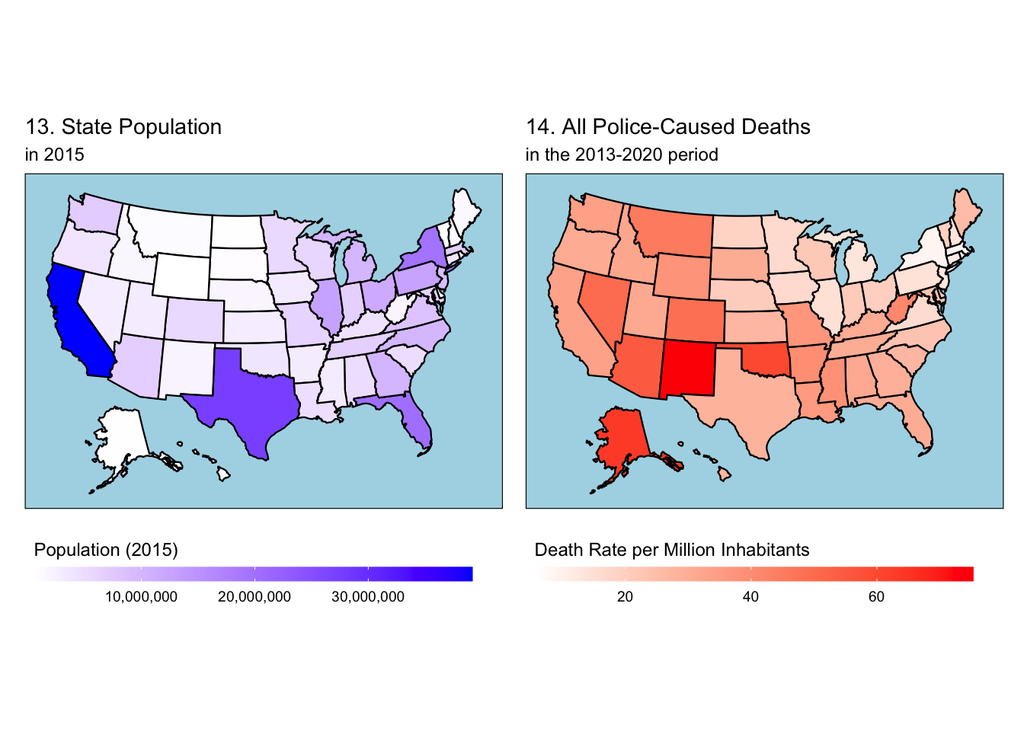

```r
p9+p10
```

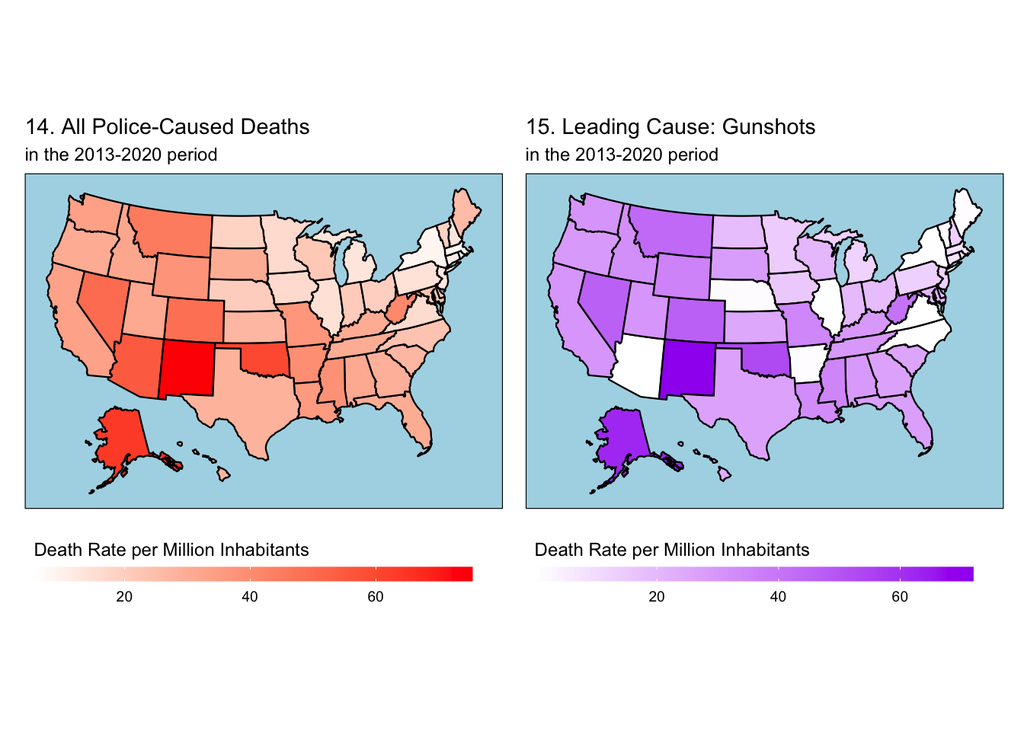

```r
p10+p11
```

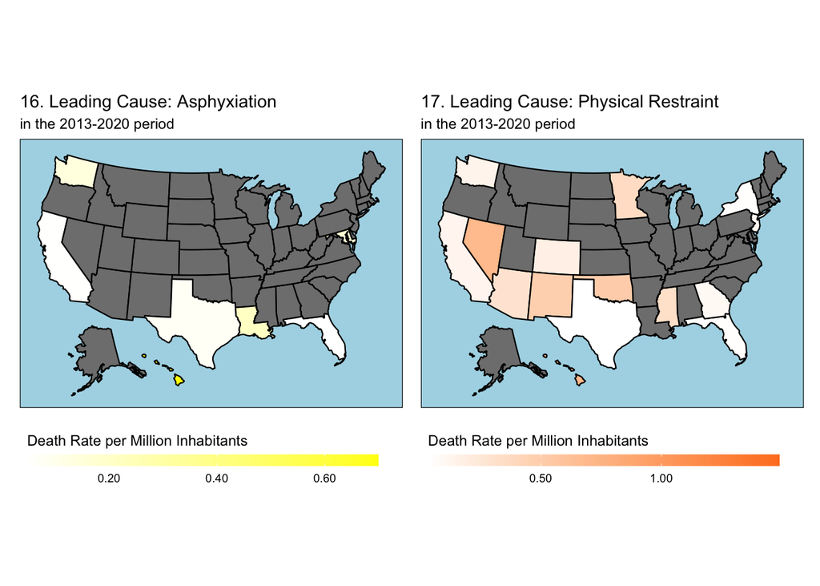

```r
p12+p13
```

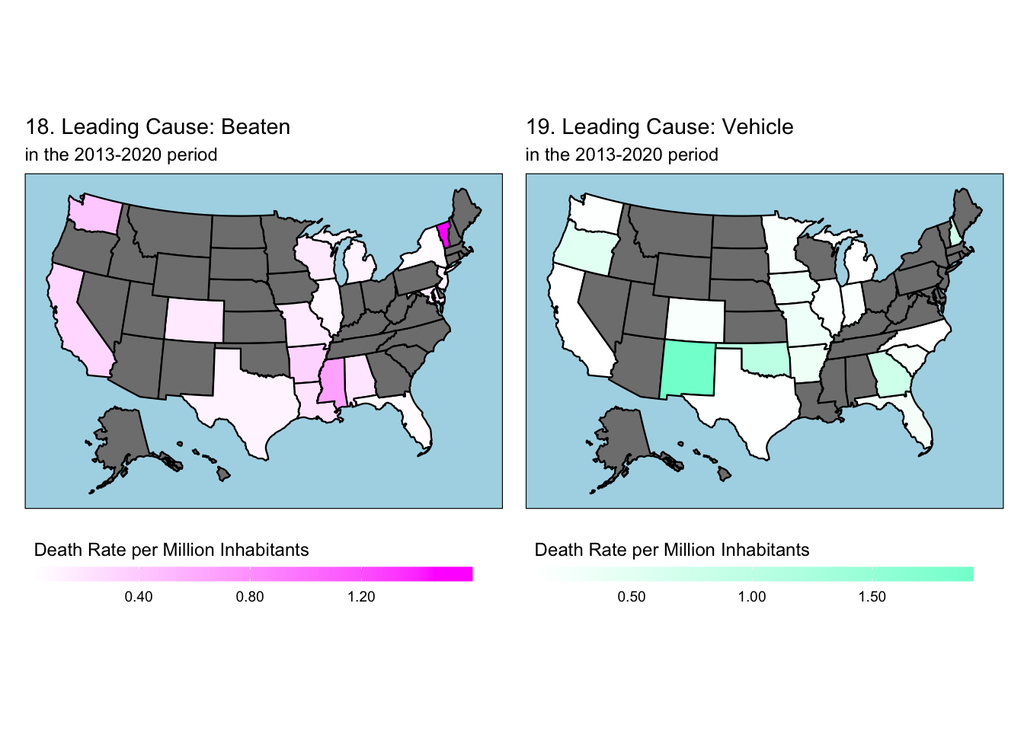

```r
p14+p15
```

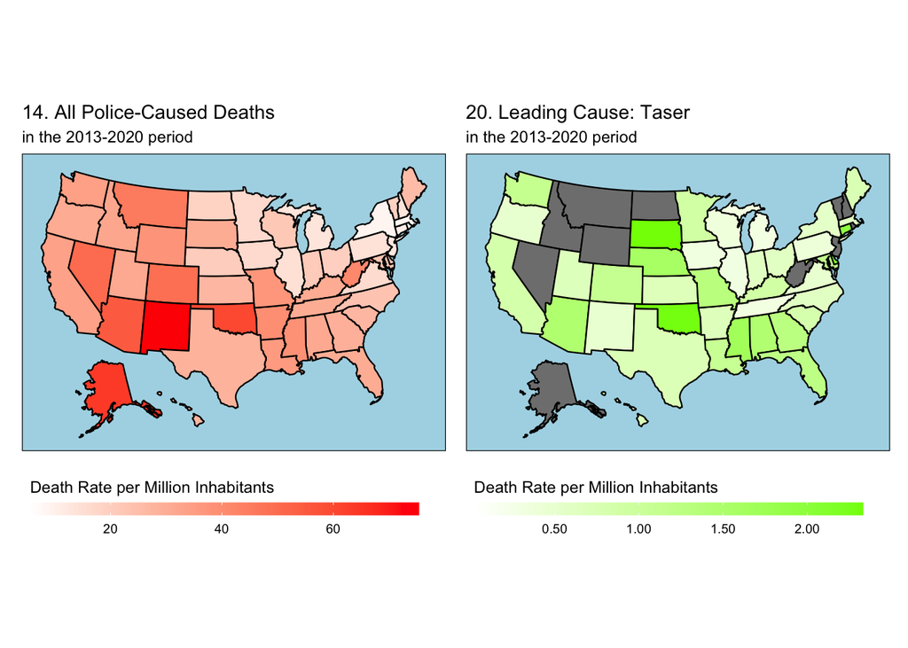

```r
p10+p16
```

## Correlations in the Mapping Police Violence Dataset

### How Police-Caused Deaths Relate to Race, Age, and Geography

R. Miranda

October 13, 2020

#### Origin of the Dataset

https://mappingpoliceviolence.org/s/MPVDatasetDownload.xlsx with the 2013-2020 record of Police killings.

#### Description of the Dataset

The MPV project defines Police Killing as a case where a person dies as a result of being shot, beaten, restrained, intentionally hit by a police vehicle, pepper sprayed, tasered, or otherwise harmed by police officers, whether on-duty or off-duty.

A person was coded as unarmed when not holding any weapon or object when killed; when household/personal objects were not used to attach; when holding toy weapons; when bystanders or hostages were killed by the police; and when persons were hit by police cars. A person was coded as allegedly armed under other circumstances.

A person was coded as using a vehicle as a weapon when killed by police while driving to attack; when killed while escaping by car at high speeds. Persons who crash without being hit by the police, or are hit and killed by a civilian driver are not included in the database.

The variables include the victim’s name, gender, race, face image if available at fatalencounters.org, date of incident, address, city, state, zip, county, agency or police department responsible for incident and the ORI identifier, the cause of death, a brief description of the encounter, the officiall disposition of the case at present, whether criminal charges exist, link to news article, symptoms of mental illness, whether victim was unarmed, alleged weapon from the Washington Post database, alleged level of threat from the Washington Post, fleeing circumstance from the Washington Post, body camera (from the Washington Post), Washington Post identifier, off-duty police status, geography (suburban, rural, etc., from Trulia population density map), MPV identifier and Fatal Encounters identifier.

The dataset is rich in details. Additional information is also available from the linked records, such as the background of the police officers (previous killings committed) and of the victims (e.g., on parole) when available. That information was not obtained for the current project.

#### Manipulation of the Dataset

The dataset was reasonably structured and clean, requiring some but not extensive manipulation. It was examined using Excel filtering to check for obvious problems. The continuous variables were converted to numeric (when used), particularly the dates and zips.

Only a subset of 18 variables were selected for further analysis: Age, Gender, Race, Date, City, State, Zipcode, County, Agency, Cause, Disposition, Charges, Mental, Unarmed, Weapon, Threat, Fleeing, Camera. In the end, because of lack of time, the only variables employed in the analysis were Age, Gender, Race, Date, and State.

Variables with long names were shortened as shown for convenient use in R statements. A complication was that variable names with spaces, special characters, etc., are converted to periods when saving Excel as .csv. Line 48 of the code shows the necessary cleaning. Some of the gender entries had trailing spaces that needed to be eliminated for efficient sorting. Race values were also shortened, as shown in line 50-55.

#### Exploratory data analysis of gender and race

The initial exploration was the distribution of dead victims according to gender. Code line 60 shows grouping by gender and summarizing all shootings by gender (shooting is the generic term used here for a dead victim.) Ggplot bargraph was used.

As depicted in Fig. 1 bar chart, the vast majority are males, 5% are females, and a small minority are transgender or unknown.

In terms of racial distribution, black victims amount to 26% of shootings, hispanic are 17%, white are 45%, asian and native groups are 2.5% and the remainder are of unknown race. It is important to notice that black plus hispanic victims amount to about 95% of white victims, more than the make-up of the population.

#### Using the package “patchwork” for some of the figures

In order to place figures side to side or special arrangements, we used “patchwork”, a package downloaded from cran.rstudio.com and documented at the top of the code. This was used for Fig. 2 and subsequent ones.

#### Exploratory data analysis of time distribution

We explored the daily and cumulative number of shootings over the 2013-2020 period, in code lines 86-122. The shootings were separated for males, females, transgender and other. Fig. 3 shows an uncomfortable steady level of daily shootings over the 7.7 year period, at about 2.9 deaths per day for males and about 0.15 deaths per day for females, showing no sign of improvement over the period. Figs. 4 and 5 show the cumulative increase over time for all genders, and the constant slope conveys the same conclusion.

#### Analysis of interaction between race and age

In code 144-157 we looked at how race affects the age distribution of victims. Figs. 10-12 show that the mean for black victims is lower, at about 27 years of age, than for hispanic at about 28 and white victims at 30 years of age.

#### Analysis of shootings by State and cause of death

In code 160-196 we explored the usmap library and the plot_usmap package to visualize shootings by state and cause of death.

We joined the MPV dataset and the StatePopulation dataset, and in line 195 defined the death rate as deaths/state-population per million inhabitants.

We filtered out the following causes of death: Gunshot, Asphyxiation, Physical Restraint, Beating, Vehicle and Taser, and plotted the sums by state on the USA map, with color intensity scaled according to death rate.

#### What could be done better

The analysis of these factors corroborate results presented by others and are not surprising at this stage. With more effort, other aspects of the same MPV dataset could analyzed in depth, such as relations between unarmed victims and race, age, and state. Likewise, correlations of those variables with mental state could be important. With even more work, there is important information in the description of events, which could show revealing trends. The news articles, if they could be mined automatically, would be invaluable.

The Town-Hall event revealed personal experiences that started in all cases at an early age with confrontations against police personnel who were not well trained to understand actions of young individuals. Many of those confrontations could lead to unjustified police violence. This project actually confirms that sadly death rises dramatically between 15 and 30 years of age.

In terms of graphics, this project gave me the opportunity to start exploring some visualization techniques. The mapping packages are of course very nice and I could learn a lot more. The next step is to include more quantitative information in them, as well as interactive features.